# Sahadeo_Lab3

R.S.

2025-02-25

# Regression model of life expectancy in 2023 on life expectancy in 1923

```r
world_life <- read.csv("C:/Users/supaq/OneDrive/Desktop/Rutgers Courses/Statistical Inference for Data Science/Lab 1/lex.csv")

world_life100 <- world_life %>%
  rename_with(~gsub("X", "", .x)) %>%
  select(Country = country,
         Life_Expectancy_1923 = '1923',
         Life_Expectancy_2023 = '2023') %>%
  drop_na()

model <- lm(Life_Expectancy_2023 ~ Life_Expectancy_1923, world_life100)

summary(model)
```

```
##
## Call:
## lm(formula = Life_Expectancy_2023 ~ Life_Expectancy_1923, data = world_life100)
##
## Residuals:
##     Min      1Q  Median      3Q     Max
## -72.326  -3.739   1.655   4.421  14.352
##
## Coefficients:
##                      Estimate Std. Error t value Pr(>|t|)
## (Intercept)          58.44949    2.56357  22.800  < 2e-16 ***
## Life_Expectancy_1923  0.38123    0.06622   5.757 3.53e-08 ***
## ---
## Signif. codes:  0 '***' 0.001 '**' 0.01 '*' 0.05 '.' 0.1 ' ' 1
##
## Residual standard error: 8.235 on 184 degrees of freedom
## Multiple R-squared:  0.1526, Adjusted R-squared:  0.148
## F-statistic: 33.14 on 1 and 184 DF,  p-value: 3.534e-08
```

### 1. Get the QQ plot of the residuals

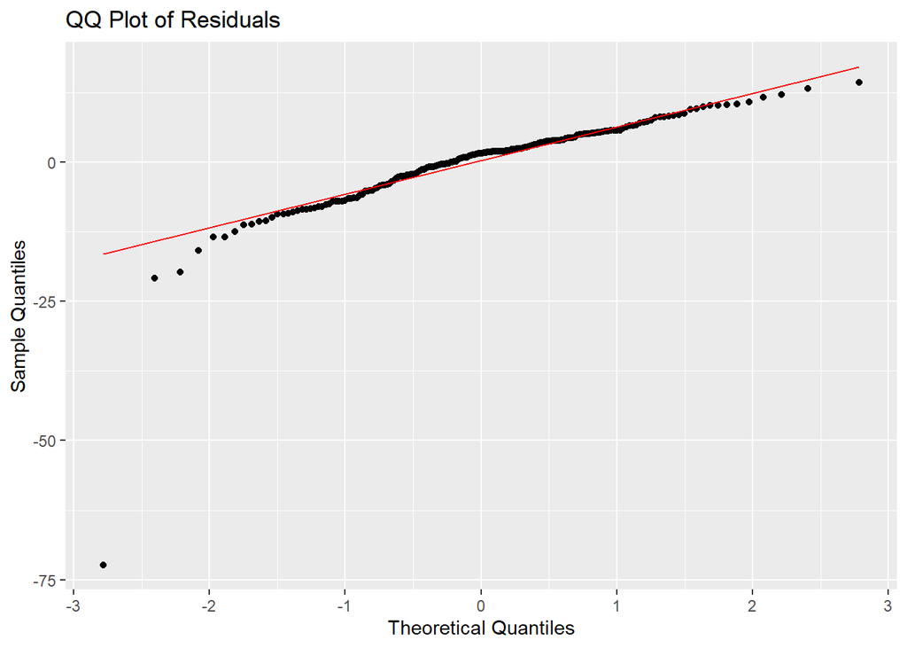

```r
residuals <- residuals(model)

ggplot(data.frame(sample = residuals), aes(sample = sample)) +
  stat_qq() +
  stat_qq_line(color = "red") +
  labs(x = "Theoretical Quantiles", y = "Sample Quantiles", title = "QQ Plot of Residuals")
```

The residuals look normally distributed but have an extreme outlier to the left.

This violates the regression assumption of normality.

### 2. Together with histogram of residual and scatter plot of residual vs. x, check the four assumptions in regression. Explain why or why not for violations in regression

Scatter Plot

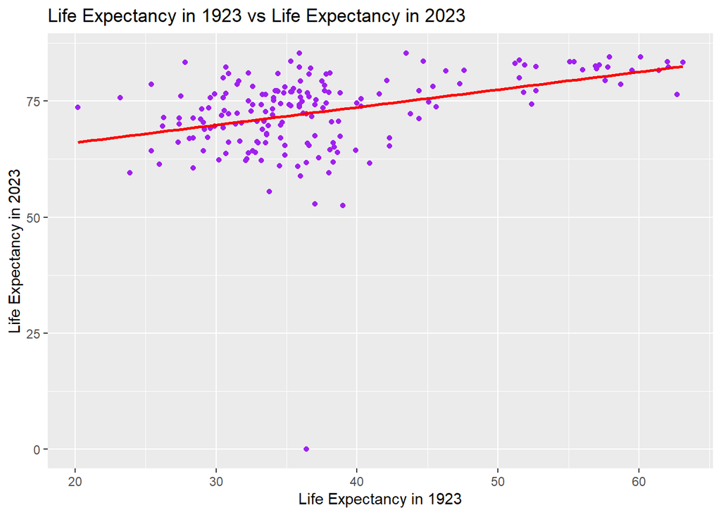

```r
ggplot(world_life100, aes(x = Life_Expectancy_1923, y = Life_Expectancy_2023))+
  geom_point(color = "purple") +
  geom_smooth(method = "lm", se = FALSE, color = "red") +
  labs(x = "Life Expectancy in 1923",
       y = "Life Expectancy in 2023",
       title = "Life Expectancy in 1923 vs Life Expectancy in 2023")
```

The red line shows a positive linear relationship between life expectancy in 1923 and 2023.

Histogram of the residuals

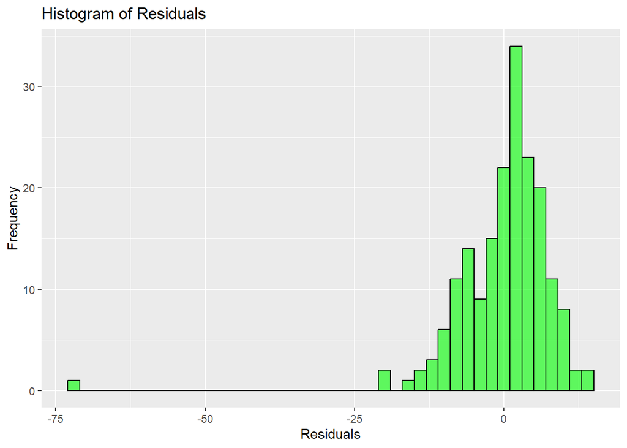

```r
ggplot(data.frame(residuals = residuals), aes(x = residuals)) +
  geom_histogram(binwidth = 2, fill = "green", color = "black", alpha = 0.6) +
  labs(title = "Histogram of Residuals", x = "Residuals", y = "Frequency")
```

Histogram of residuals confirms one extreme outlier, which affects normality.

The distribution is slightly skewed to the left, mostly due to the affect of the outlier.

The QQ plot and histogram are used to check normality.

Scatter plot of Residuals vs Independent Variable (x = Life_Expectancy_1923)

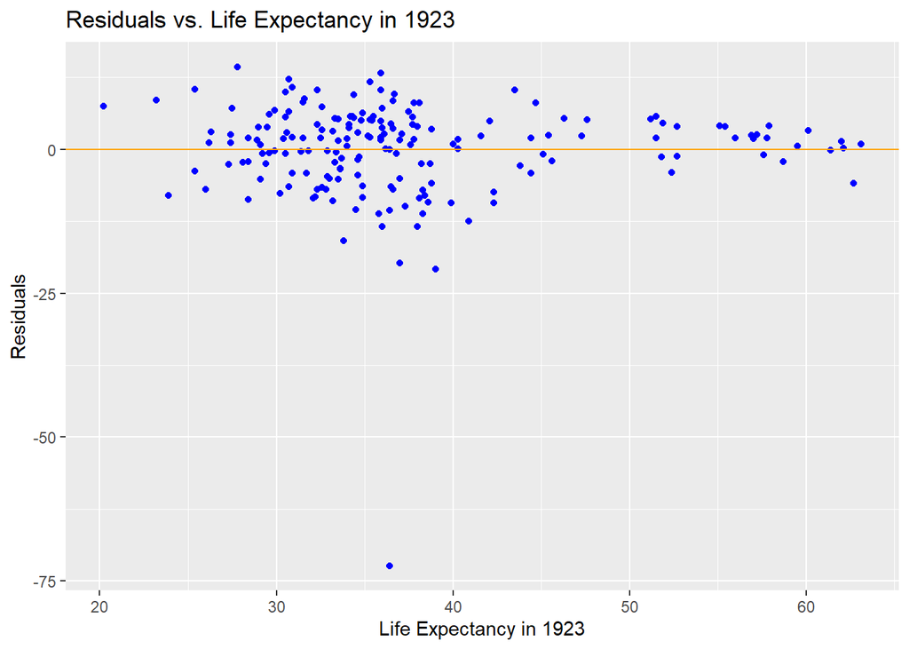

```r
world_life100$residuals <- residuals(model)

ggplot(world_life100, aes(x = Life_Expectancy_1923, y = residuals)) +
  geom_point(color = "blue") +
  geom_hline(yintercept = 0, linetype = "solid", color = "orange") +
  labs(x = "Life Expectancy in 1923",
       y = "Residuals",
       title = "Residuals vs. Life Expectancy in 1923")
```

The points are randomly scattered above and below the line at y = 0.

Linearity is satisfied since the scatter plot of life expectancy in 1923 vs life expectancy in 2023 confirms a mild positive linear relationship.

Independence is assumed since we are working with a data set that consists of life expectancy from different countries, we can assume independence.

Normality is partially violated due to an outlier. The QQ plot and histogram show that residuals mostly follow a normal distribution except for an extreme outlier.

# Galton’s Height Data

### Let’s read the data set

```r
galton_data <- read.csv("C:/Users/supaq/OneDrive/Desktop/Rutgers Courses/Statistical Inference for Data Science/Lab 3/galton height.csv")
```

### 1. Obtain a scatterplot of y vs. x. On top of scatterplot, add the regression line and the diagonal line y=x, with different colors

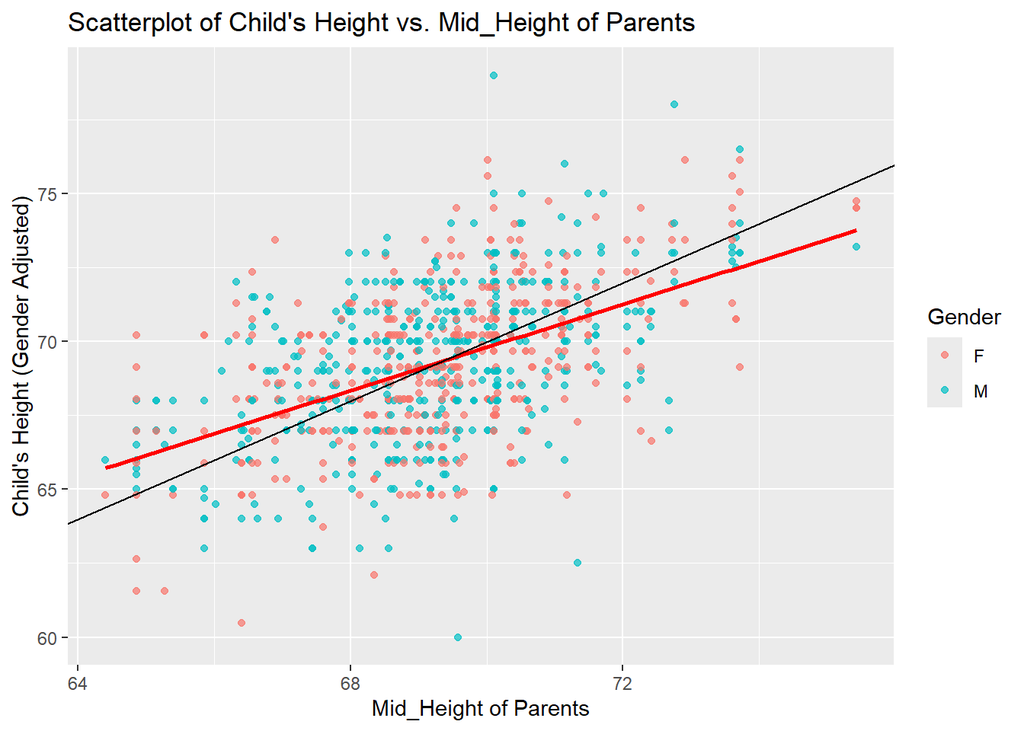

```r
height_data <- galton_data %>%
  mutate(Adjusted_Height = ifelse(Gender == "F", Height * 1.08, Height)) %>%
  mutate(Mid_Height_Parent = (Father + (Mother * 1.08)) / 2)

ggplot(height_data, aes(x = Mid_Height_Parent, y = Adjusted_Height,
                        color = Gender)) +
  geom_point(alpha = 0.7) +
  geom_smooth(method = "lm", se = FALSE, color = "red") +
  geom_abline(intercept = 0, slope = 1, color = "black", linetype = "solid") +
  labs(x = "Mid_Height of Parents",
       y = "Child's Height (Gender Adjusted)",
       color = "Gender",
       title = "Scatterplot of Child's Height vs. Mid_Height of Parents")
```

This scatter plot visualizes the relationship between Child’s Height vs. Mid-Height of Parent, with the height of the mother and daughter multiplied by 1.08 for adjustment. The model presents a red regression line that shows a positive correlation between the predictor variable, Mid-Height of Parents on the response variable, the Child’s height. A black diagonal line represents the y=x line, a hypothetical scenario where a child would be exactly as tall as the mid-height of the parent. However, due to regression to the mean, if a point falls above the black line, the child is taller than their parents’ mid-height. If a point falls below the black line, the child is shorter than the mid-height of their parents. To distinguish male children from female children, color was added to represent the gender, Blue for male, red for female.

### 2. What is the average children’s height in the data? What is the average mid-height of the parent?

```r
mean_child_height <- mean(height_data$Adjusted_Height)

mean_mid_height_parent <- mean(height_data$Mid_Height_Parent)

mean_child_height
```

```
## [1] 69.23371
```

```r
mean_mid_height_parent
```

```
## [1] 69.22201
```

While the values are very close, this result does not fully align with the expectation of regression to the mean. Instead it suggest a small increase in height rather than a reversal toward the population mean.

### 3. Among parents whose mid-height between 72 and 73 inches, what is the average height of their children?

```r
height_compare <- height_data %>%
  filter(Mid_Height_Parent >= 72 & Mid_Height_Parent <= 73)

mean_child_compare <- mean(height_compare$Adjusted_Height)

mean_child_compare
```

```
## [1] 71.3178
```

The average height of children whose parents have a mid-height between 72-73 inches is 71.32 inches, below the mid-height of their parents, but still taller than the child mean height of 69.23 inches.

### 4. Run regression, is the model significant?

```r
child_model <- lm(Adjusted_Height ~ Mid_Height_Parent, data =  height_data)

get_regression_table(child_model)
```

```
## # A tibble: 2 × 7
##   term              estimate std_error statistic p_value lower_ci upper_ci
##   <chr>                <dbl>     <dbl>     <dbl>   <dbl>    <dbl>    <dbl>
## 1 intercept           18.8       2.84       6.61       0   13.2      24.3
## 2 Mid_Height_Parent    0.729     0.041     17.8        0    0.649     0.81
```

```r
summary(child_model)
```

```
##
## Call:
## lm(formula = Adjusted_Height ~ Mid_Height_Parent, data = height_data)
##
## Residuals:
##     Min      1Q  Median      3Q     Max
## -9.4947 -1.4779  0.0995  1.5175  9.1262
##
## Coefficients:
##                   Estimate Std. Error t value Pr(>|t|)
## (Intercept)       18.76698    2.84062   6.607 6.74e-11 ***
## Mid_Height_Parent  0.72906    0.04102  17.772  < 2e-16 ***
## ---
## Signif. codes:  0 '***' 0.001 '**' 0.01 '*' 0.05 '.' 0.1 ' ' 1
##
## Residual standard error: 2.233 on 896 degrees of freedom
## Multiple R-squared:  0.2606, Adjusted R-squared:  0.2598
## F-statistic: 315.9 on 1 and 896 DF,  p-value: < 2.2e-16
```

The regression model is statistically significant with a p-value < 2e-16. However, it only explains 26.06% of the variability in the child height.

### 5. If the parents’ mid-height increases by 1 inch, what is the expected increase in child’s height? Is the expected increase larger or smaller than 1 inch?

For every 1-inch increase in mid-height of parent, the child’s height is expected to increase by 0.729 inches. The increase is less than 1, demonstrating regression to the mean. This suggests tall parents have children who are tall but slightly shorter than themselves and short parents have children who are short but slightly taller than themselves.

### 6. Estimate the child’s height if the mid-height of parent is 64, 68, 70, 72, 76 respectively, and check their “closeness” to the mean height of all children

```r
parent_height <- data.frame(Mid_Height_Parent = c(64, 68, 70, 72, 76))

estimated_child_heights <- predict(child_model, parent_height)

estimated_child_heights
```

```
##        1        2        3        4        5
## 65.42658 68.34280 69.80092 71.25903 74.17525
```

```r
closeness_to_mean <- abs(estimated_child_heights - mean_child_height)

data.frame(Mid_Height_Parent = parent_height$Mid_Height_Parent,
           Estimated_Child_Heights = estimated_child_heights,
           Closeness_To_Mean = closeness_to_mean)
```

```
##   Mid_Height_Parent Estimated_Child_Heights Closeness_To_Mean
## 1                64                65.42658         3.8071363
## 2                68                68.34280         0.8909115
## 3                70                69.80092         0.5672008
## 4                72                71.25903         2.0253132
## 5                76                74.17525         4.9415380
```

The estimated child heights for mid-height parents of 64, 68, 70, 72, and 76 inches follow the regressions model’s predictions. The closeness to mean confirms regression to the mean. A child’s height moves toward the population average rather than replicating their parents’ height. Taller than average parents have children who are slightly shorter than them, while shorter than average parents have children who are slightly taller than them.

# Regression of mid-height of parent on child’s height

### 1. Obtain a scatterplot of y vs. x. On top of scatterplot, add the regression line and the diagonal line y=x, with different colors

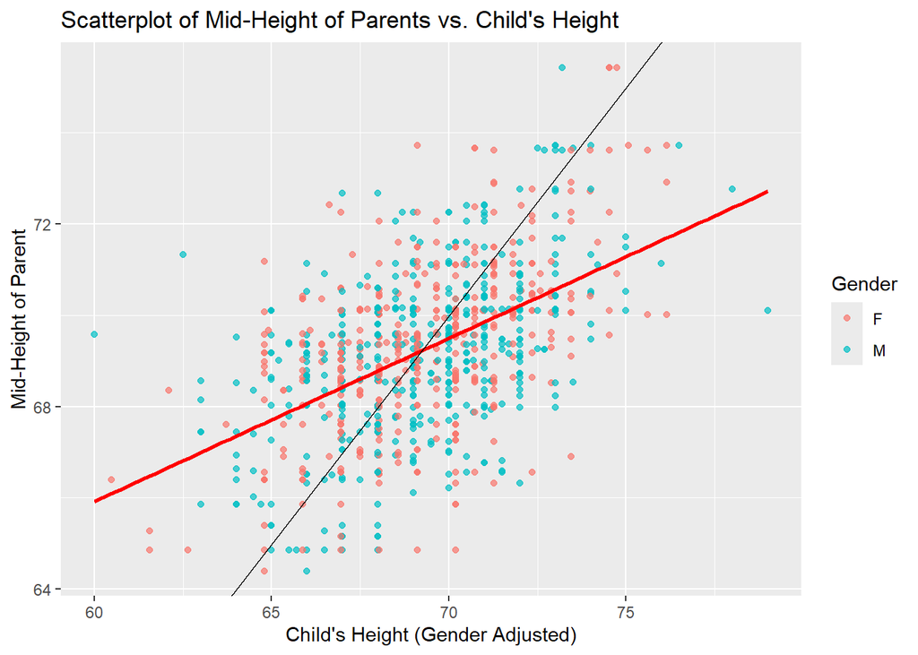

```r
ggplot(height_data, aes(x = Adjusted_Height,
                        y = Mid_Height_Parent, color = Gender)) +
  geom_point(alpha = 0.7) +
  geom_smooth(method = "lm", se = FALSE, color = "red") +
  geom_abline(intercept = 0, slope = 1, color = "black", linetype = "solid") +
  labs(x = "Child's Height (Gender Adjusted)",
       y = "Mid-Height of Parent",
       title = "Scatterplot of Mid-Height of Parents vs. Child's Height")
```

This scatter plot visualizes the relationship between a child’s height and the mid-height of their parents. The positive correlation confirms that taller children tend to have taller parents and shorter children tend to have shorter parents. However, the red regression line shows that childrens’ height move toward the population average rather than perfectly mirroring their parents’ mid-height, thus demonstrating regression to the mean. This means that extremely tall children often have parents with a mid-height that is shorter than their own, while extremely short children have parents with a mid-height that is taller than their own.

### 2. Among all children with height between 72 and 73 inches, what is the mean mid-height of their parents?

```r
child_height_compare <- height_data %>%
  filter(Adjusted_Height >= 72 & Adjusted_Height <= 73)

mean_parent <- mean(child_height_compare$Mid_Height_Parent, na.rm = TRUE)

mean_parent
```

```
## [1] 70.29489
```

The mean of mid-height of parent for children who are between 72-73 is 70.29 inches.

### 3. Run regression, is the model significant?

```r
parent_model <- lm(Mid_Height_Parent ~ Adjusted_Height, height_data)

summary(parent_model)
```

```
##
## Call:
## lm(formula = Mid_Height_Parent ~ Adjusted_Height, data = height_data)
##
## Residuals:
##     Min      1Q  Median      3Q     Max
## -4.7075 -1.0556  0.0547  1.0163  4.7901
##
## Coefficients:
##                 Estimate Std. Error t value Pr(>|t|)
## (Intercept)     44.47115    1.39365   31.91   <2e-16 ***
## Adjusted_Height  0.35750    0.02012   17.77   <2e-16 ***
## ---
## Signif. codes:  0 '***' 0.001 '**' 0.01 '*' 0.05 '.' 0.1 ' ' 1
##
## Residual standard error: 1.564 on 896 degrees of freedom
## Multiple R-squared:  0.2606, Adjusted R-squared:  0.2598
## F-statistic: 315.9 on 1 and 896 DF,  p-value: < 2.2e-16
```

The model is statistically significant with a p-value of 2e-16, confirming a relationship between a child’s adjusted height and their parents mid-height. The regression coefficient 0.3575 indicates that for even i-inch increase in the child’s height, the parents’ mid-height is expected to increase by only 0.3575 inches. The supports the concept of regression to the mean where, taller than average children have parents whose mid-height moves toward the mean of the mid-height of parents. Similarly shorter than average children tend to have parents whose mid-height moves toward the mean of the mid-height of parents. However the model has an R-squared value of 0.2606 meaning that a child’s height explains only 26.06% of the variation in parents’ mid-height.

### 4. If the child’s height increases by 1 inch, what is the expected increase in parent’s mid-height? Is the expected increase larger or smaller than 1 inch?

If the child’s height increases by 1 inch the, mid-height of parents is expected to increase by 0.3575 inches. Since this is less than 1, this also supports regression to the mean where extremely tall children have slightly shorter parents, and extremely short children tend to have slightly taller parents. The key idea is that height extremes move toward the population average across generations.

### 5. Estimate the parent’s mid-height if the child’s height is 64, 68, 70, 72, 76 respectively, and check their “closeness” to the mean mid-height of all parents

```r
child_height <- data.frame(Adjusted_Height = c(64, 68, 70, 72, 76))

predicted_parents <- predict(parent_model, child_height)

closeness_to_mean_parents <- abs(predicted_parents - mean_mid_height_parent)

data.frame(Child_Height = child_height$Adjusted_Height,
           Predicted_Parents = predicted_parents,
           Closeness_To_Mean_Parents = closeness_to_mean_parents)
```

```
##   Child_Height Predicted_Parents Closeness_To_Mean_Parents
## 1           64          67.35097                 1.8710379
## 2           68          68.78096                 0.4410495
## 3           70          69.49595                 0.2739447
## 4           72          70.21095                 0.9889389
## 5           76          71.64093                 2.4189273
```

Using our regression model, we estimated parent mid-heights for children with heights 64, 68, 70, 72, and 76 inches. The results show that as child height moves away from the population mean, the predicted parent mid-height moves toward the mean, following the principle of regression to the mean.

### Use the above results to explain regression to the mean

Regression to the mean occurs when extreme values in one variable tend to be associated with less extreme values in another variable. In this case:

Very tall children tend to have parents who are not as tall as they are.

Very short children tend to have parents who are not as short as they are.

The results show that children with extreme heights have parents whose mid-height is closer to the overall population mean than their own height. For example, a child who is 64 inches tall has a predicted mid-height parent height of 67.35 inches, higher than the child’s height and closer to the mean of the mid-height of parents. While a child who is 76 inches tall has an estimated mid-height parent of 71.64 inches, lower than the child’s height and closer to the population mean of the mid-height of parents. This pattern demonstrates regression to the mean where children with extreme heights have parents with mid-heights the are closer to the over all population mean.